# ETC5513: Collaborative and Reproducible Practices

## Exercise 3: Hands on practice with COVID-19 Data

1. The data for the tutorial is inside a folder called Data, which is bundled with the RStudio Project. Find that file in the lower right pane where all your files are listed.
2. Create a new section heading in your `qmd` document to read the data with the title “Reading Coronavirus Data”  
   Hint: Use `#`
3. Inside this new section, create an R Code Chunk with options `echo: true`, `warning: false`, `message: false` called “Reading data” and insert the following code:

```r
dat <- read_csv("Data/COVID19_March12_Hubei.csv")
```

4. Insert a new R Chunk and find out what information you can get from the command `head(dat)`
5. Modify the `head` command to display 10 rows.
6. Create another two R chunks and use in each of them the R functions `glimpse()` and `str()`. What information can you get from those commands?  
   Hint: For more information on R functions, type in the R conolse `?glimpse()`.
7. Using an R inline command, write the dimension of the dataset in a sentence.  
   Hint: Have a look at `ncol` and `nrow`.
8. Add a new subsection heading (`###`) with “Why is it important to know the dimension of your dataset?” and write a brief sentence with the explanation
9. Add a new subsection heading (`###`) with “What are the variable names in the dataset?” and display the names of the dataset variables using R.  
   Hint: `?names()` in the R consolee
10. Select two variables and use a markdown list to briefly explain what each of the variables are measuring.

**Solution**

2. The R chunk should look like this:

````markdown
# Reading data

```{r loading_data}
#| echo: true
#| warning: false
#| message: false

dat <- read_csv("Data/COVID19_March12_Hubei.csv")
```
````

```r
glimpse(dat)
```

```
Rows: 21,241
Columns: 9
$ ID                      <dbl> 1, 2, 3, 4, 5, 6, 7, 8, 9, 10, 11, 12, 13, 14,…
$ age                     <chr> "30", "47", "49", "47", "50", NA, "42", NA, "5…
$ sex                     <chr> "male", "male", "male", "female", "female", NA…
$ city                    <chr> "Chaohu City, Hefei City", "Baohe District, He…
$ province                <chr> "Anhui", "Anhui", "Anhui", "Anhui", "Anhui", "…
$ country                 <chr> "China", "China", "China", "China", "China", "…
$ latitude                <dbl> 31.64696, 31.77863, 31.82831, 31.82831, 32.001…
$ longitude               <dbl> 117.7166, 117.3319, 117.2248, 117.2248, 117.56…
$ date_admission_hospital <chr> "20.01.2020", "21.01.2020", "20.01.2020", "20.…
```

```r
str(dat)
```

```
spc_tbl_ [21,241 × 9] (S3: spec_tbl_df/tbl_df/tbl/data.frame)
 $ ID                     : num [1:21241] 1 2 3 4 5 6 7 8 9 10 ...
 $ age                    : chr [1:21241] "30" "47" "49" "47" ...
 $ sex                    : chr [1:21241] "male" "male" "male" "female" ...
 $ city                   : chr [1:21241] "Chaohu City, Hefei City" "Baohe District, Hefei City" "High-Tech Zone, Hefei City" "High-Tech Zone, Hefei City" ...
 $ province               : chr [1:21241] "Anhui" "Anhui" "Anhui" "Anhui" ...
 $ country                : chr [1:21241] "China" "China" "China" "China" ...
 $ latitude               : num [1:21241] 31.6 31.8 31.8 31.8 32 ...
 $ longitude              : num [1:21241] 118 117 117 117 118 ...
 $ date_admission_hospital: chr [1:21241] "20.01.2020" "21.01.2020" "20.01.2020" "20.01.2020" ...
 - attr(*, "spec")=
  .. cols(
  ..   ID = col_double(),
  ..   age = col_character(),
  ..   sex = col_character(),
  ..   city = col_character(),
  ..   province = col_character(),
  ..   country = col_character(),
  ..   latitude = col_double(),
  ..   longitude = col_double(),
  ..   date_admission_hospital = col_character()
  .. )
 - attr(*, "problems")=<externalptr>
```

and for good measure

```r
head(dat, n=10)
```

```
# A tibble: 10 × 9
      ID age   sex    city                   province country latitude longitude
   <dbl> <chr> <chr>  <chr>                  <chr>    <chr>      <dbl>     <dbl>
 1     1 30    male   Chaohu City, Hefei Ci… Anhui    China       31.6      118.
 2     2 47    male   Baohe District, Hefei… Anhui    China       31.8      117.
 3     3 49    male   High-Tech Zone, Hefei… Anhui    China       31.8      117.
 4     4 47    female High-Tech Zone, Hefei… Anhui    China       31.8      117.
 5     5 50    female Feidong County, Hefei… Anhui    China       32.0      118.
 6     6 <NA>  <NA>   Lu'an City             Anhui    China       31.8      116.
 7     7 42    female Fuyang City            Anhui    China       32.9      116.
 8     8 <NA>  female Huaibei City           Anhui    China       33.7      117.
 9     9 59    female Huainan City           Anhui    China       32.8      117.
10    10 30    male   Hefei City             Anhui    China       31.8      117.
# ℹ 1 more variable: date_admission_hospital <chr>
```

7. Code example:

```
The dataset has `r nrow(dat)` rows and `r ncol(dat)` variables.
```

Output: The dataset has 21241 rows and 9 variables.

8. Example markdown:

````
### Why is it important to know the dimension of your dataset?
It is important because it will help you to better understand the
structure of your data set. It will provide a clear information
about how many variables and how many individual cases  are
in your data.

### What are the variable names in the dataset?
```{r}
names(dat)
```
````

- `age`: Contains the age in years of the individual. Class `character`.
- `sex`: Provides the sex of the individual. One of `male` or `female`. Class `character`.

Output:

### Why is it important to know the dimension of your dataset?

It is important because it will help you to better understand the structure of your data set. It will provide a clear information about how many variables and how many individual cases are in your data.

### What are the variable names in the dataset?

```r
names(dat)
```

```
[1] "ID"                      "age"
[3] "sex"                     "city"
[5] "province"                "country"
[7] "latitude"                "longitude"
[9] "date_admission_hospital"
```

## Exercise 4: COVID19 Data Wrangling

1. Using the R package `dplyr` (which is loaded with `tidyverse`), and using the pipe (`|>`), create a new dataset called `data_cleaned` that only contains the following variables:
   - `country`
   - `age`
   - `sex`
   - `city`
   - `province`
   - `latitude`
   - `longitude`

**Solution**

```r
data_cleaned <- dat %>%
    select(country, age, sex, city, province, latitude, longitude)
```

2. Inspect `data_cleaned` and describe using a markdown list the type of variables in this new dataset. Write the names of the variables in bold. Do you think the variable attributes are correct?

**Solution**

```
* `age` is a character (`<chr>`)
* `sex` is a character (`<chr>`)
* `city` is a character  `<chr>`
* `province` is a character  `<chr>`
* `latitute` is double (numeric) `<dbl>`
* `Longitude` is double (numeric) `<dbl>`
```

We would expect `age` to be numeric not a character.

3. Convert the variable `age` into a numeric vector

**Solution**

We’ll overwrite `data_cleaned` here but you could but it in a new object if we wanted to.

```r
data_cleaned <- data_cleaned |>
    mutate(age = as.numeric(age))
```

4. Inspect the first 20 values of `age`. What do you observe? What is the proportion of missing values in the variable `age`? Make sure you round the results to two decimal numbers.

**Solution**

```r
head(data_cleaned$age, 20)
```

```
 [1] 30 47 49 47 50 NA 42 NA 59 30 NA 39 NA 38 45 NA NA 33 NA NA
```

We can see here there are a lot of missing values. The proportion of missing values can be calculated as

```r
round(sum(is.na(data_cleaned$age))/length(data_cleaned$age), digits = 2)
```

```
[1] 0.94
```

5. Remove cases for which we don’t have information on the person’s age and keep cases for which the gender of the patient is known. Give this new data set the name `data_filtered`.

**Solution**

```r
data_filtered <- data_cleaned |>
    filter(!is.na(age), sex %in% c("male", "female"))
```

6. What is the dimension of this new data set? Compare it with the dimension of `cleaned_data`. How many cases have we lost?

**Solution**

```r
dim(data_filtered)
```

```
[1] 1210    7
```

```r
dim(data_cleaned)
```

```
[1] 21241     7
```

We have lost 20031 cases for which we did not have information about age or gender.

7. Examine the variable age using the function `summary()`. Do you see any problems in the data?

**Solution**

```r
summary(data_filtered$age)
```

```
    Min.  1st Qu.   Median     Mean  3rd Qu.     Max.
 0.08333 32.00000 44.00000 44.56136 56.00000 96.00000
```

8. Remove patient entries with age below 1. You can save this back into `data_filtered`.

**Solution**

```r
data_filtered <- data_filtered |>
    filter(age >= 1)
```

9. Provide a table summary of the variable age using the `kable()` function from the `kableExtra` package. Give it the caption “COVID-19 Age Summary”.

**Solution**

```r
data_filtered |>
    select(age) |>
    summary() |>
    kable(caption = "COVID-19 Age Summary")
```

COVID-19 Age Summary

|  | age |
| --- | --- |
|  | Min. : 1.00 |
|  | 1st Qu.:32.00 |
|  | Median :44.00 |
|  | Mean :44.71 |
|  | 3rd Qu.:56.00 |
|  | Max. :96.00 |

10. Visualize the age distribution using a histogram and give an explanation about the information that a histogram convey. In addition change the x label in the plot to *Age* and remove the y axis label.  
    Hint: You’ll need to use `ggplot2` for this.

**Solution**

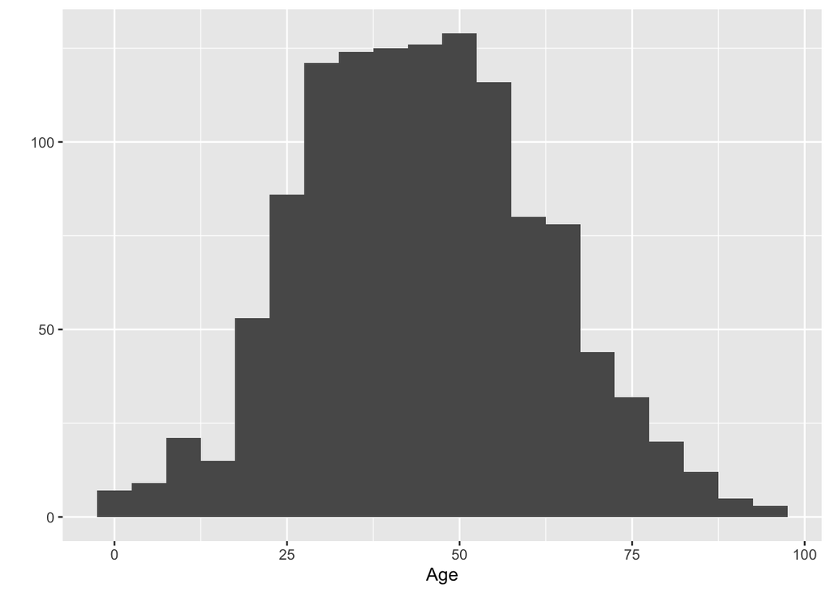

```r
data_filtered |>
    ggplot(aes(x=age)) +
    geom_histogram(binwidth = 5) +
    labs(x="Age", y="")
```

11. Change the color of the histogram using `geom_histogram(color = "blue", fill = "white")`

**Solution**

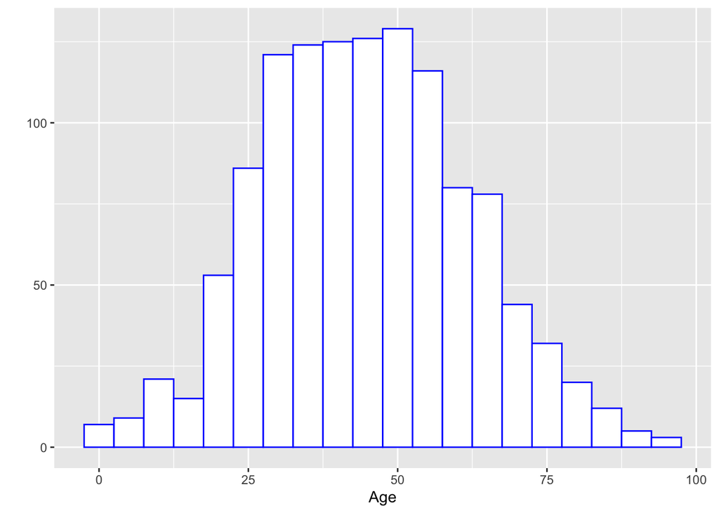

```r
data_filtered |>
    ggplot(aes(x = age)) +
    geom_histogram(color = "blue", fill="white", binwidth = 5) +
    labs(x = "Age", y = "")
```

12. Visualize the age distribution for females and males and add the following caption to the figure *“Age frequencies of COVID19 patients in China per gender”*  
    (Hint: `facet_wrap()`)

**Solution**

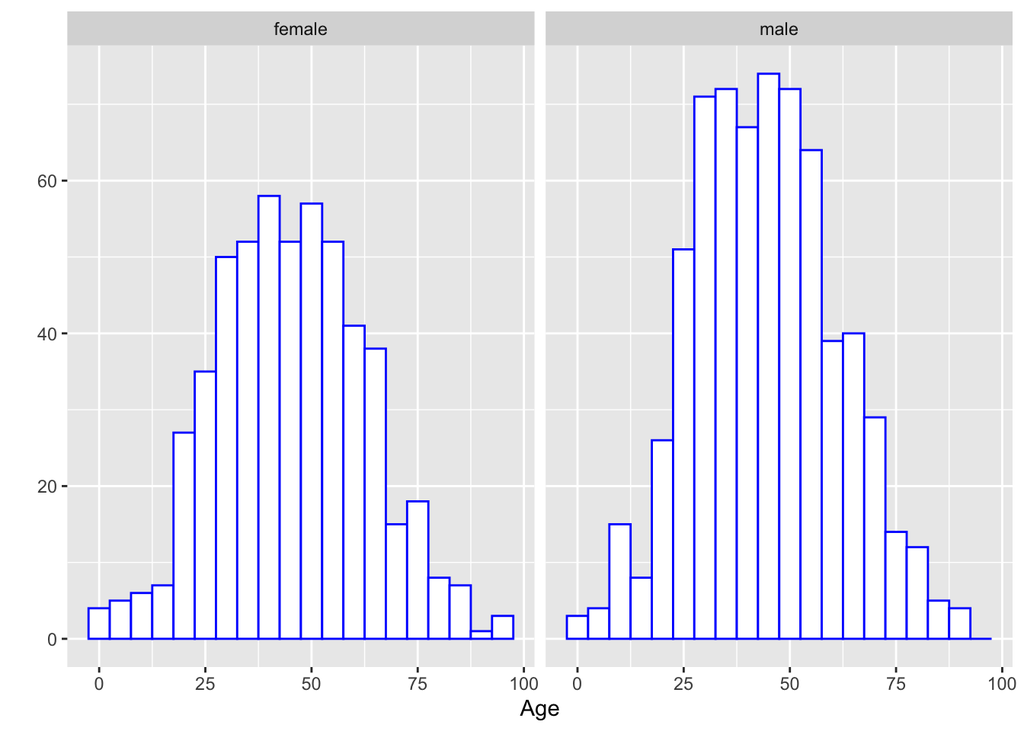

Age frequencies of COVID19 patients in China per gender

````markdown
```{r}
#| fig-cap: Age frequencies of COVID19 patients in China per gender
data_filtered |>
    ggplot(aes(x = age)) +
    geom_histogram(color = "blue", fill = "white", binwidth = 5) +
    labs(x = "Age", y = "") +
    facet_wrap(~sex)
```
````

13. Count the number of cases per province and display a table of the top 10 provinces. Store results into an object called `cases_by_province`.  
    : Replace XXX by the adequate variable names in the code below.

````markdown
```{r}
cases_by_province <- data_filtered |>
  select(XXX) |>
  filter(!is.na(XXX)) |>
  group_by(province) |>
  summarise(cases = n())|>
  arrange(-XXX)
```
````

**Solution**

```r
cases_by_province <- data_filtered |>
  select(province) |>
  filter(!is.na(province)) |>
  group_by(province) |>
  summarise(cases = n()) |>
  arrange(-cases)

cases_by_province |>
    slice(1:10) |>
    kable(caption = "Number of cases by province")
```

Number of cases by province

| province | cases |
| --- | --- |
| Shaanxi | 109 |
| Anhui | 91 |
| Gansu | 72 |
| Jilin | 63 |
| Guizhou | 57 |
| Baden-Wurttemberg | 56 |
| Yunnan | 49 |
| Beijing | 45 |
| Hong Kong | 39 |
| Guangxi | 35 |

14. Recreate this table using the below code:

````markdown
```{r}
cases_by_province_alternative <- data_filtered |>
    filter(!is.na(province)) |>
    count(province, name="cases", sort=TRUE)
```
````

**Solution**

```r
cases_by_province_alternative <- data_filtered |>
    filter(!is.na(province)) |>
    count(province, name="cases", sort=TRUE)

cases_by_province_alternative |>
    slice(1:10) |>
    kable(caption = "Number of cases by province")
```

Number of cases by province

| province | cases |
| --- | --- |
| Shaanxi | 109 |
| Anhui | 91 |
| Gansu | 72 |
| Jilin | 63 |
| Guizhou | 57 |
| Baden-Wurttemberg | 56 |
| Yunnan | 49 |
| Beijing | 45 |
| Hong Kong | 39 |
| Guangxi | 35 |